# Práctica Variable Aleatoria Unidimensional

Javier Cano

29 de octubre de 2016

# 1. Calcula k para que f(x) sea realmente una funcion de densidad

Sea `func` la función definida en el enunciado de la práctica. Para que sea una función de densidad debe cumplirse que la integral de la función entre -Infinito e Infinito sea igual a 1, por lo que es necesario calcular una `k` que cumpla esta restricción.

Con `k=1` tenemos la siguiente función.

```r
func <- function(x){
  ifelse(x>=5&x<=25,(25-x),0)
}

integrate(func,-Inf,Inf)
```

```
## 199.9999 with absolute error < 0.013
```

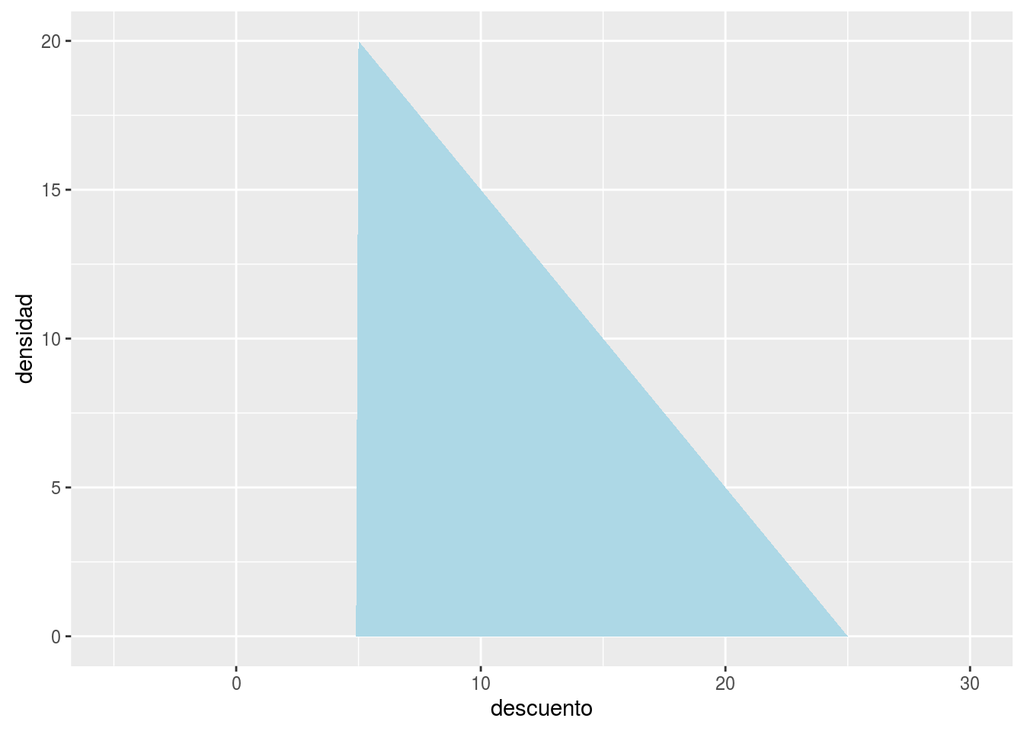

```r
descuento <- seq(-5,30,0.1)
densidad <- func(descuento)
ggplot(data.frame(descuento,densidad),aes(x=descuento,y=densidad)) + geom_area(fill="lightblue")
```

La integral de la función es 200. Despejando `k`, nos queda `k=1/200`.

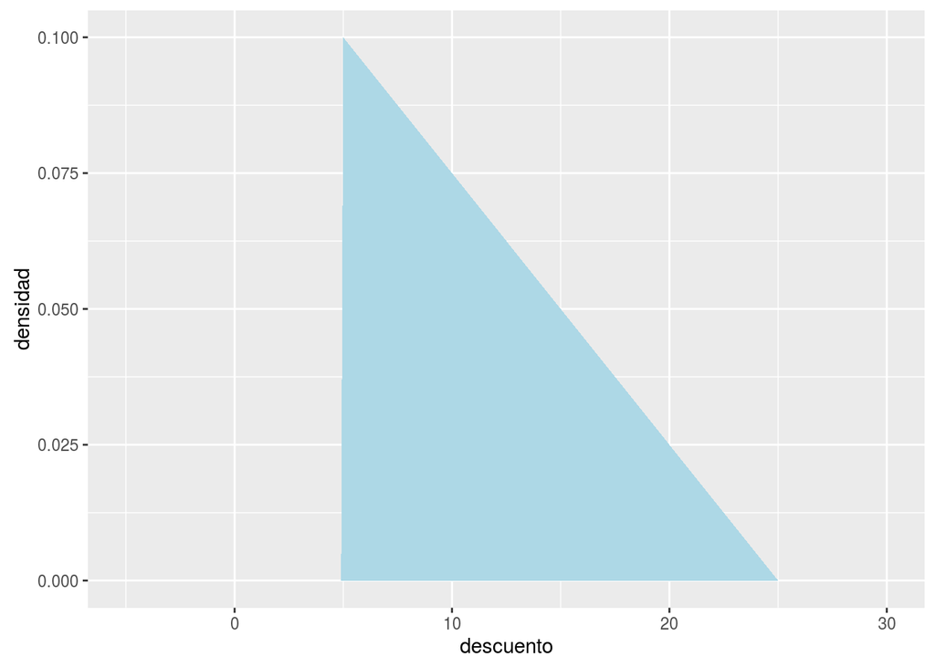

```r
func <- function(x){
  k <- 1/200
  ifelse(x>=5&x<=25,(25-x)*k,0)
}
densidad <- func(descuento)
p <- ggplot(data.frame(descuento,densidad),aes(x=descuento,y=densidad)) + geom_area(fill="lightblue")
plot(p)
```

Comprobamos que la integral de la función cumple que la integral entre -Infinito e Infinito es igual a 1.

```r
integrate(func,-Inf,Inf)
```

```
## 0.9999994 with absolute error < 6.6e-05
```

# 2. Calcula la probabilidad de que un cliente obtenga más de un 20% de descuento

La probabilidad es igual a la integral de la función entre 20 e infinito:

```r
integrate(func,20,Inf)
```

```
## 0.06250054 with absolute error < 0.00011
```

El área marcada en la siguiente gráfica corresponde con el valor de la integral.

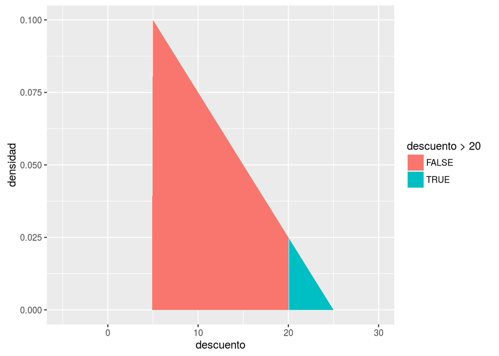

```r
p + geom_area(aes(fill=descuento>20))
```

# 3. ¿Cuál es el descuento medio que se espera aplicar?

Como la función es continua, la media se obtiene aplicando la integral entre -Infinito e Infinito de `x*func(x)`.

```r
fmedia <- function(x){x*func(x)}
media <- integrate(fmedia,-Inf,Inf)
media
```

```
## 11.66663 with absolute error < 0.00031
```

En el siguiente gráfico se representa el valor de la media en la función de densidad.

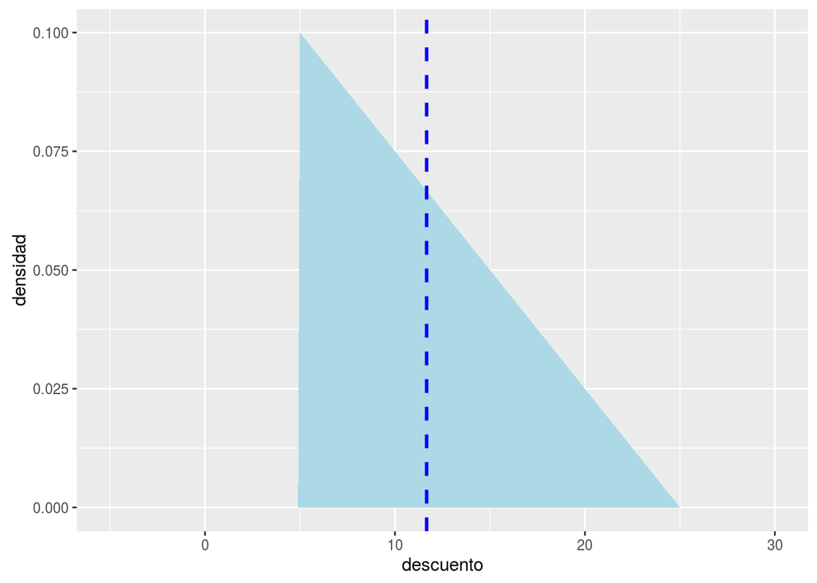

```r
p + geom_vline(aes(xintercept=media$value), color="blue", linetype="dashed", size=1)
```

# 4. Calcula la varianza de la variable aleatoria

Para calcular la varianza de una función continua, se obtiene calculando el momento de orden 2 y restándole el cuadrado de la media.

```r
fesperanza <- function(x){(x^2)*func(x)}
varianza <- integrate(fesperanza,-Inf,Inf)$value - media$value^2
varianza
```

```
## [1] 22.22263
```

# 5 ¿Entre qué valores estarán probablemente la mitad de los descuentos realizados?

Para calcular los valores entre los que estarán la mitad de los descuentos realizados usamos la desigualdad de Chebyshev.

```r
inferior <- media$value-sqrt(2)*sqrt(varianza)
superior <- media$value+sqrt(2)*sqrt(varianza)
inferior
```

```
## [1] 4.999898
```

```r
superior
```

```
## [1] 18.33335
```

A continuación se muestran gráficamente:

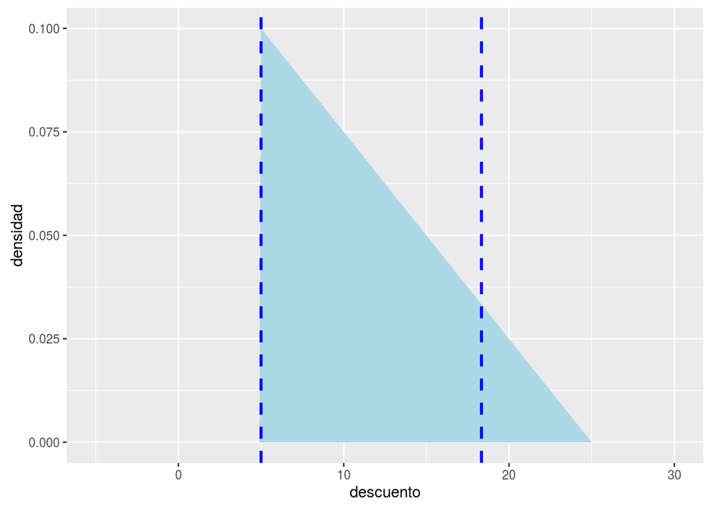

```r
p + geom_vline(aes(xintercept=inferior), color="blue", linetype="dashed", size=1) + geom_vline(aes(xintercept=superior), color="blue", linetype="dashed", size=1)
```

# 6. ¿Cuál es la moda de la variable aleatoria?

La moda es el valor que obtiene el resultado máximo en la función de densidad.

```r
descuento[which(densidad==max(func(descuento)))]
```

```
## [1] 5
```

# 7. Calcula la mediana de la variable aleatoria

Primero hay que calcular la función de distribución. Para ello integramos la función de densidad (usando wolframalpha) y obtenemos la siguiente función.

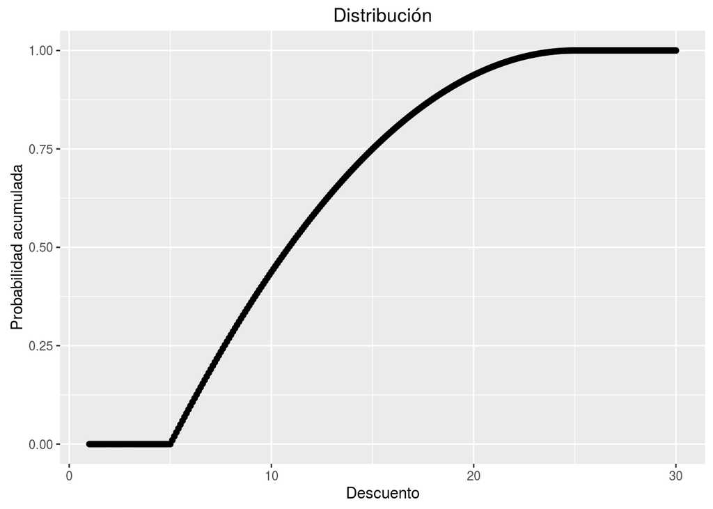

```r
func_d <- function(x){
  ifelse(x>=5,
         ifelse(x<=25,(x/8 - x^2/400)-0.5625,1)
         ,0)
}

x2 <- seq(1,30,0.1)
y2 <- func_d(x2)
q <- qplot(x2,y2) + labs(title="Distribución", x="Descuento", y="Probabilidad acumulada")
q
```

A partir de la función de distribución, obtenemos su función inversa (usando wolframalpha) y calculamos el cuantil 50 o mediana.

```r
func_di <- function(p){
  25-20*sqrt(1-p)
}

func_di(0.5)
```

```
## [1] 10.85786
```

A continuación, representamos gráficamente la mediana

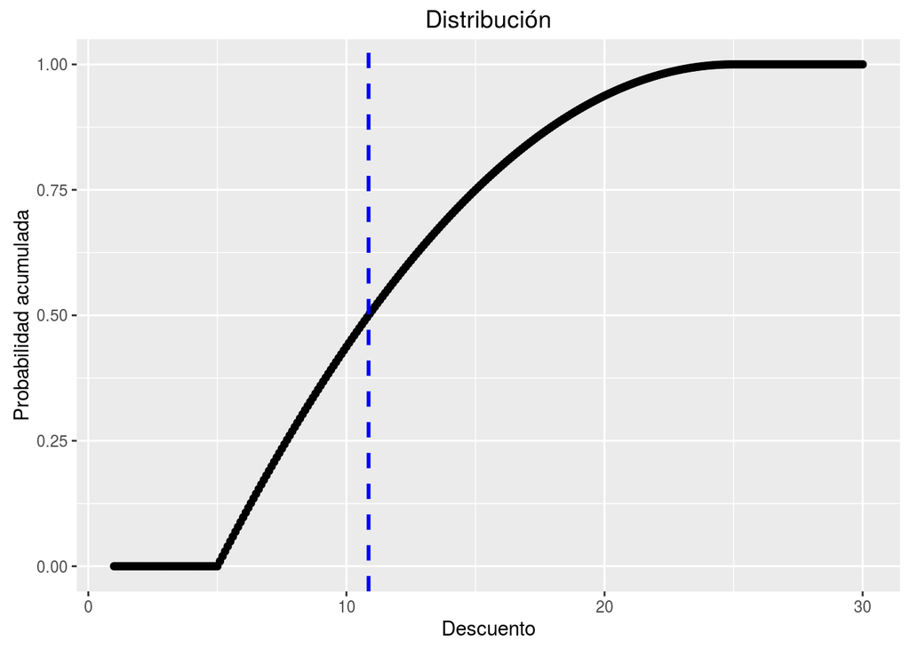

```r
q + geom_vline(aes(xintercept=func_di(0.5)), color="blue", linetype="dashed", size=1)
```